# DSA2101_Project_Group208

2023-11-17

# 1. Introduction

Our group chose to work on the FIFA world cup dataset. It comprises of two datasets, namely `wcmatches` and `worldcups`. `wcmatches` contains every match played from 1930 to 2018, and contains various information regarding each match such as the the time each match was played under `date` and `month`, the location the match was held under columns `country` and `city`, the winner of each match under `winning team`, as well as more football-related information such as the number of goals scored by each team, winning conditions and the stage of the tournament in which the game was played in. The `worldcups` dataset contains information regarding the year, host country and the countries of the top four winning teams. Some football-related information such as total goal scored, games played and more were included as well. Given the hugehuge assortment of of data provided to us, our group came up with an interesting question: **“What makes a champion, a champion?”**. We analyzed various factors that could potentially contribute to the champion’s path to glory. We focused on three different factors, namely *geographical influence*, the *total goals scored by the winning team*, and *overall winning percentage*.

### Loading All Required Libraries

```r
library(tidyverse)
library(maps)
library(ggplot2)
library(countrycode)
library(sf)
library(dplyr)
library(lubridate)
library(gridExtra)
```

### Loading All Datasets

```r
tuesdata <- tidytuesdayR::tt_load('2022-11-29')
tuesdata <- tidytuesdayR::tt_load(2022, week = 48)
wcmatches <- tuesdata$wcmatches
worldcups <- tuesdata$worldcups
```

# 2. Data Cleaning and Summary

Our team split data cleaning and manipulation into three main portions based on the three different visualizations. We will only talk about some of the main transformations performed in aid of our visualizations.

For `Visualization 1`, we generalized the original “group X” for the various values of X under the `stage` column in `wcmatches` into just “group stage”, as the specific group was not required for our visualization. We also replaced the “Round of 16” stage into “RO16” for easy reference. We also cleaned up the round-robin like final played in 195o to include each team only once, as it is key for our visualization later on.`home_scores` and `away_scores` were calculated to find the total goals scored by both home and away teams. They are then merged into a single dataframe named `combined_score` to compute the performance map as seen in `Visualization 1`. Finally, we cleaned up the namings of some countries, such as combining *“West Germany”* into *“Germany”*, and *“UK”* with *“England”*

For `Visualization 2`, we mainly select the year column in the `worldcups` dataset and merged it with the `wcmatches` dataset to form a single dataframe called `champions_data`. We then used this dataframe to compute the winning percentage and goal difference against total goals scored. For `Visualization 3`, we renamed the column names from home and away team to team A and B for easier reference.

## Data Cleaning for Visualization 1.1

```r
wcmatches$stage <- sub(".*group.*", "Group Stage", wcmatches$stage, ignore.case = TRUE)
wcmatches$stage <- sub(".*16.*", "RO16", wcmatches$stage)
wc_games <- wcmatches %>%
  filter(stage != "Final Round" |
         (stage == "Final Round" &
          ((home_team == "Brazil" & away_team == "Uruguay") |
           (home_team == "Spain" & away_team == "Sweden")))) %>%
  mutate(stage = ifelse(stage == "Final Round", "Final", stage))

combined_data <- wc_games %>%
  select(year, stage, home_team, away_team)

stage_scores <- c("Group Stage" = 1, "RO16" = 2, "Quarterfinals" = 3, "Semifinals" = 6, "Third place" = 7, "Final" = 8)

home_scores <- combined_data %>%
  group_by(home_team) %>%
  summarise(score = sum(stage_scores[stage])) %>%
  rename(country = home_team)

away_scores <- combined_data %>%
  group_by(away_team) %>%
  summarise(score = sum(stage_scores[stage])) %>%
  rename(country = away_team)

combined_scores <- full_join(home_scores, away_scores, by = "country") %>%
  mutate(score = ifelse(is.na(score.x), score.y, ifelse(is.na(score.y), score.x, score.x + score.y))) %>%
  select(country, score) %>%
  arrange(desc(score))
```

## Data Cleaning for Visualization 1.2

```r
# Import data from "map" library for Visualisation 1
world = map_data("world") %>%
  filter(region != "Antarctica")

# Fix Missing England on Map, as it was labelled as UK in the "map" data
world <- world %>%
  mutate(region = ifelse(region == "UK", "England", region))

winners_map <- left_join(world, worldcups, c("region" = "winner"))
performance_map <- left_join(world, combined_scores, c("region" = "country"))
performance_map <- performance_map %>%
  mutate(score = ifelse(is.na(score), 0, score))

host_map <- map_data("world", region = worldcups$host)

# Summarize Each Country's Winning Count
winners_counts <- worldcups %>%
  group_by(winner) %>%
  summarise(wins = n()) %>%
  # Merging West Germany's Wins with Germany's
  mutate(wins = ifelse(winner == "Germany", wins + sum(wins[winner == "West Germany"]), wins)) %>%
  filter(winner != "West Germany") %>%
  arrange(desc(wins))

# Summarize Central Coordinate of Each Country
world_coordinates <- world %>%
  group_by(region) %>%
  summarise(
    avg_long = mean(long),
    avg_lat = mean(lat)
  )

# Fixing missing coordinate for England
duplicated_row <- world_coordinates[world_coordinates$region == "UK", ]
duplicated_row$region <- sub("UK", "England", duplicated_row$region, ignore.case = TRUE)
world_coordinates <- rbind(world_coordinates, duplicated_row)

# Winning Country's Coordinates
winners_counts <- left_join(winners_counts, world_coordinates, by = c("winner" = "region"))
```

```r
# Data Cleaning
champions <- worldcups %>%
  select(year, winner)

champions_data <- wcmatches %>%
  select(year, home_team, away_team, home_score, away_score, outcome) %>% #select only necessary columns
  left_join(champions, by = "year") %>% #combine with another table
  filter(winner == home_team | winner == away_team) #filter for champion data

# Calculate winning percentage
winning_percentage <- champions_data %>%
  mutate(winner_team = ifelse(outcome == "H", home_team, away_team)) %>%
  mutate(if_win = ifelse(winner == winner_team, 1, 0)) %>%
  group_by(year) %>%
  summarize(total_games = n(),
            games_won = sum(if_win)) %>%
  ungroup() %>%
  mutate(Ratio = games_won / total_games) %>%
  mutate(Year = year)

w = worldcups%>%
  select(year, goals_scored)

# Calculate goal difference against total goals scored
goal_difference_against_goals_scored <- champions_data %>%
  mutate(goals_scored = ifelse(winner == home_team, home_score, away_score),
         goals_lost = ifelse(winner == home_team, away_score, home_score))%>%
  select(year, winner, goals_scored, goals_lost, goals_scored) %>%
  group_by(year) %>%
  summarize(total_goals_scored = sum(goals_scored),
            total_goals_lost = sum(goals_lost)) %>%
  ungroup() %>%
  mutate(ratio = ((total_goals_scored - total_goals_lost)/total_goals_scored )) %>%
  mutate(Year = year, Ratio = ratio) %>%
  select(Year,Ratio)
```

### Data Cleaning and Visualization 3

```r
# Data Cleaning
df_1 <- wcmatches %>%
  #mutate(stage = ifelse(startsWith(stage, "Group"), "Group Stage", stage)) %>%
  rename(
    team_A=home_team,
    team_B=away_team,
    team_A_score=home_score,
    team_B_score=away_score,
  ) %>%
  mutate(outcome = winning_team) %>%
  select(-outcome, -losing_team, -month) %>%
  left_join(worldcups, by = "year") %>%
  mutate_all(~str_replace_all(., "United States", "USA")) %>%
  rename (`1st` = winner,
          `2nd` = second,
          `3rd` = third,
          `4th` = fourth)


# Rearrange data
df_2 <- df_1 %>% select(year, 5:8, 14:17)%>%
    mutate(top_teams = paste(`1st`,`2nd`,`3rd`,`4th`,sep=" ")) %>%
   filter(str_detect(top_teams,team_A) | str_detect(top_teams,team_B))

# filter out teams and scores
df_team <- df_2 %>% select(year, team_A, team_B) %>%
  pivot_longer(cols = c(team_A, team_B), values_to = "team") %>% select(-name)

df_2$team_A_score <- as.numeric(df_2$team_A_score)
df_2$team_B_score <- as.numeric(df_2$team_B_score)

df_score <- df_2 %>% select(year, team_A_score, team_B_score) %>%
  pivot_longer(cols = c(team_A_score, team_B_score), values_to = "score") %>% select(-name)

df_top <- df_2 %>% select(year, top_teams) %>% unique()

df_rank <-df_2 %>% select (year, 6:9) %>% unique() %>% pivot_longer(cols = c(`1st`,`2nd`,`3rd`,`4th`), names_to = "rank", values_to = "team")

df_3 <- data.frame(
  year = df_team$year,
  team = df_team$team,
  score = df_score$score
) %>%
  left_join(df_top, by = "year") %>%
  filter(str_detect(top_teams, team)) %>%
  group_by(year, team) %>%
  summarize(total_score = sum(score, na.rm = TRUE)) %>%
  left_join(df_rank, by = c("year","team")) %>%
  arrange(year, rank)
```

# 3. Visualizations

## Visualization 1

### *Each Country’s Geographical Location and Overall World Cup Performance*

This visualization aims to highlight the dominant role played by geographical distribution as the leading factor in the makings of a World Cup champion. We displayed the performance of every country in every past world cup by awarding varying points for each match played, with higher points for rounds further into the tournament, we also highlighted each country that has won the world cup with a **yellow dot.** This would allow us to analyse how the geographical location of a country affects its chances of becoming a World Cup champion, and what some underlying, indirect factors are.Football as we know of today originated in England, with European countries being the first to formalise the sport with standardised rules in the 1840s, and was brought over to South America through the ports of Buenos Aires, Argentina by European sailors just a couple of decades later. (Weil, E. , Rollin, . Jack , et. al., 2023). From the visualisation, we can also see that the countries from these continents perform significantly better than other continents, which can be seen from the darker colours in these two regions.

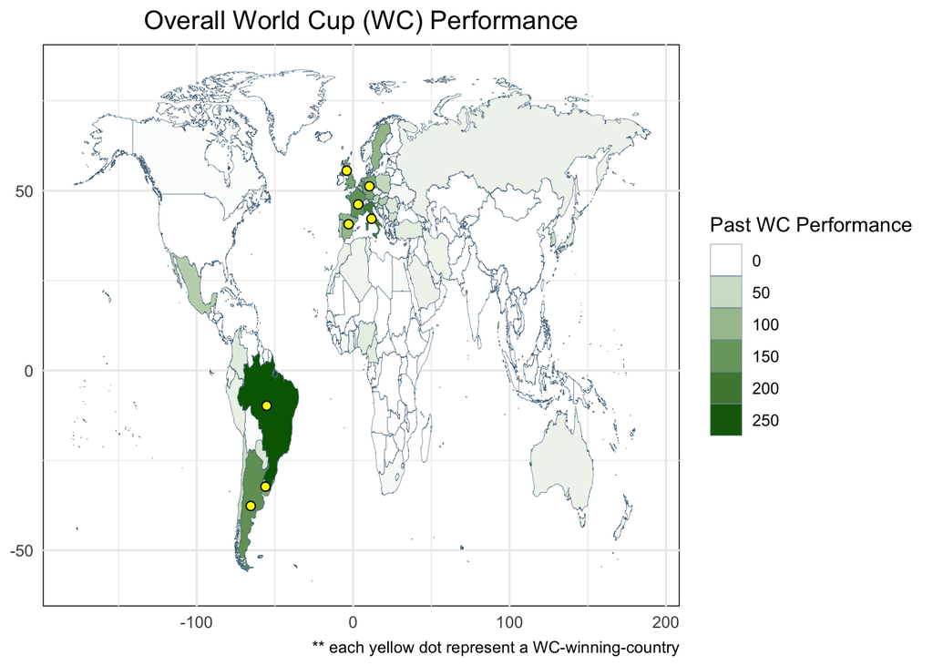

```r
ggplot(data = world, aes(x = long, y = lat, group = group)) +
  geom_polygon(data = world, aes(x = long, y = lat, group = group), fill = "lightgray") +
  geom_polygon(data = performance_map, aes(x = long, y = lat, group = group, fill = score), show.legend = TRUE, color = "#496c85", size=0.1) +
  scale_fill_gradient(low = "white", high = "darkgreen") +  # Adjust color values as needed
  geom_point(data = winners_counts, aes(x = avg_long, y = avg_lat), inherit.aes = FALSE, size = 2, pch=21, color="black", fill="yellow", show.legend = FALSE) +
  theme_minimal() +
  labs(title = "Overall World Cup (WC) Performance",
       caption = "** each yellow dot represent a WC-winning-country") +
  theme(
    axis.title = element_blank(),
    plot.title = element_text(hjust = 0.5, size = 14),
    panel.background = element_rect(fill = "white")
  ) +
  guides(
    fill = guide_legend(title = "Past WC Performance"),
    shape = guide_legend(title = "Legend", override.aes = list(fill = "yellow", color = "black"), label = "Winning Nations")
  )
```

## Visualization 2

### *The Champion’s Winning Percentage and Goal Difference*

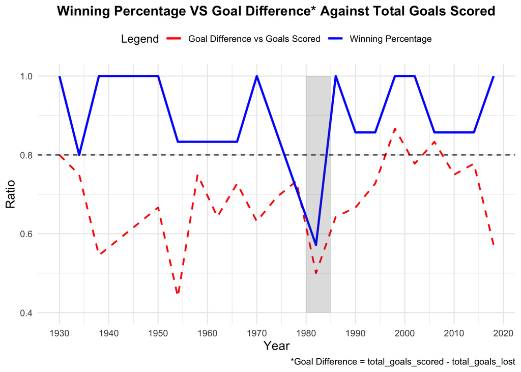

```r
ggplot() +
  geom_line(data = goal_difference_against_goals_scored ,
            aes(x=Year, y = Ratio, color = "Goal Difference vs Goals Scored"), size = 0.8,
            lty= "dashed") +
  geom_line(data = winning_percentage,
            aes(x=Year, y = Ratio, color = "Winning Percentage"), size = 1) +
  geom_hline(yintercept = 0.8,show.legend = T, lty = "dashed")+
  theme_minimal() +
  scale_x_continuous(n.breaks = 10) +
  labs(title = "Winning Percentage VS Goal Difference* Against Total Goals Scored",
       caption = "*Goal Difference = total_goals_scored - total_goals_lost") +
  scale_color_manual(name = "Legend",
                     values = c("Goal Difference vs Goals Scored" = "red",
                                "Winning Percentage" = "blue",
                                "Ratio = 0.8" = "black")) +
  theme(legend.position = "top",
        plot.title = element_text(face = "bold", size = 13,hjust = 0.5),
        axis.title = element_text(size = 12)) +
  annotate("rect", xmin = 1980, xmax = 1985, ymin = 0.4, ymax = 1, alpha = 0.2)
```

## Visualization 3

### *The Champion’s Goals Scored Compared to the Rest of Top-4 Teams*

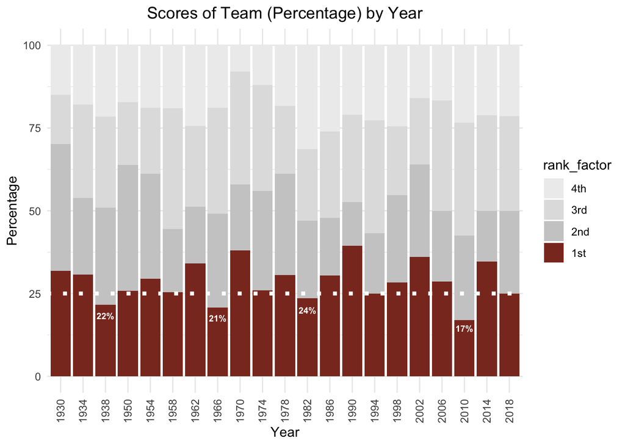

```r
total_scores <- aggregate(total_score ~ year, data = df_3, FUN = sum)
merged_data <- merge(df_3, total_scores, by = "year", suffixes = c("", "_total"))
merged_data$percentage <- (merged_data$total_score / merged_data$total_score_total) * 100
merged_data$rank_factor <- factor(merged_data$rank, levels = c("4th", "3rd", "2nd", "1st"))
custom_colors <- c("1st" = "tomato4", "2nd" = "grey80", "3rd" ="grey88", "4th" = "grey93")
bars <- merged_data[(merged_data$percentage < 25) & (merged_data$rank == "1st"), ]


ggplot(merged_data, aes(x = year, y = percentage,  fill = rank_factor)) +
  geom_bar(stat = "identity") +
  geom_hline(yintercept = 25, linetype = "dotted",lwd=1.5, color = "white")+
  geom_text(data = bars, aes(label = paste0(round(percentage, 0), "%")),
            position = position_stack(vjust = 0.85),
            size = 2.5, color = "white", show.legend = FALSE, fontface = "bold")+
  labs(title = "Scores of Team (Percentage) by Year",
       x = "Year",
       y = "Percentage") +
  scale_fill_manual(values =custom_colors) +
  theme_minimal()+
  theme(axis.text.x = element_text(angle = 90, vjust = 0.5, hjust=1))+
  theme(plot.title = element_text(hjust = 0.5))
```

# 4. Discussions

Visualisations 2 and 3 shed light on additional critical factors defining World Cup champions. Teams with higher winning percentages and goal counts are prevalent among the champions, indicating the significance of these metrics. However, it is crucial to recognize that factors such as strategic prowess and the quality of opponents also play pivotal roles in determining championship outcomes (Lepschy et al.). Therefore, becoming a World Cup champion is a multi-faceted achievement, relying on a combination of factors that make it inherently challenging to predict.

In conclusion, the path to World Cup championship is intricately woven with historical legacies, financial strengths, strategic prowess, and the ability to navigate the challenges posed by high-quality opponents. It is a nuanced journey that encompasses a multitude of variables, making it a complex and unpredictable endeavour.

# 5. References

- Brian, Phillips. (2010, July 12). Not-So-Beautiful Game. Slate. https://slate.com/culture/2010/07/spain-s-win-over-the-netherlands-brings-a-fantastic-world-cup-to-a-hacking-plodding-end.html
- Evangelos Bekris. (2018, September). Relationship between Time and Goal Scoring of European Soccer Teams with Different League Ranking. Journal of Human Sport and Exercise, vol. 13, no. 3, https://doi.org/10.14198/jhse.2018.133.04.
- Lepschy, H., Wäsche, H., & Woll, A. (n.d.). How to be successful in Football: A systematic review. The Open Sports Sciences Journal. https://opensportssciencesjournal.com/VOLUME/11/PAGE/3/
- Lopez, G. (2022, December 13). The power of history. The New York Times. https://www.nytimes.com/2022/12/13/briefing/morocco-world-cup.html
- Weil, E. , Rollin, . Jack , Joy, . Bernard , Giulianotti, . Richard C. and Alegi, . Peter Christopher (2023, November 11). football. Encyclopedia Britannica. https://www.britannica.com/sports/football-soccer